# Ecological Archives E094-065-A1

*Ecological Archives* E094-065-A1

T. Hiltunen, L. E. Jones, S. P. Ellner, N. G. Hairston Jr.. 2013. Temporal dynamics of a simple community with intraguild predation: an experimental test. *Ecology* 94:773–779. http://dx.doi.org/10.1890/12-0786.1

Appendix A. Detailed description of the experimental procedure and methods for analyzing the phase lags.

*Chemostat experiments*

The prey algae, *C. autrophica* (CCMP 243), and the flagellate intermediate predator, *O. marina* (CCMP604), were obtained from the National Center for Marine Algae and Microbiota (NCMA). The rotifers (top predators), *B. plicatilis*, were obtained from Florida Aqua Farms (FL, USA). The three-species experiments were conducted in 380-mL chemostats maintained in growth chambers held at 21°C (± 1°C) with constant illumination (120 μEm<sup>-2</sup> s<sup>-1</sup> Grolux wide spectrum fluorescent lamps). We used a modified f/2 culture medium (Guillard and Ryther 1962) with nitrogen at 80 μM/L as the limiting nutrient (all other nutrients in excess of algal requirements) and salinity adjusted to 35 g/L with commercial salt mix (Tropic Marin, MA, USA). The temperature and salinity that we used were chosen to limit somewhat rotifer growth efficiency (maximum growth rate of *B. plicatilis* occurs at 16 g/L (K. Blackley, A. Looi, and D. Rosenberg *personal communication*). In preliminary experiments, under conditions more favorable to the rotifers, the flagellates were driven to extinction by rotifer predation and competition. The dilution rate of the chemostats was 0.25/day.

Duplicate samples of all species were taken daily through two ports near the top and bottom of the chemostat. Algal and flagellates densities were counted under a compound microscope using a hemacytometer for algae (Improved Neubauer, Hausser Scientific, Horsham, PA, USA) and a Sedgewick-Rafter cell for flagellates (Wildlife Supply Co., FL, USA). Rotifers were enumerated under a dissecting microscope, as in our previous studies (Fussmann et al. 2000, Yoshida et al. 2003, Becks et al. 2010). All reported abundances are the means of the values from the top- and bottom-port samples.

*Estimating cycle period and time delays*

We estimated the cycle period and the time delays between the oscillations of different species in each of the replicate experiments using two methods. The first method estimated the cycle period and time delays from the timing of abundance peaks for each species. The data for each species were smoothed and interpolated to continuous time by cubic local polynomial regression with plugin bandwidth selection (Cabrera 2009), producing smooth population curves with well-defined peaks (Fig. 2). The elapsed time between two successive peaks of a species is an estimate of the period, so each experimental replicate yielded several estimates of the period (one or two cycle intervals per species and experiment) that we averaged to obtain an estimate for that run. Similarly, the time elapsed between a peak in the algae and the first subsequent peak in one of the predators is an estimate of the time-delay between the cycles of those two species. We used peaks rather than troughs because peaks are much sharper and their timing better defined and less affected by sampling variability. Phase lags were then obtained by dividing the estimated time delay between a species pair by the estimated period for that replicate.

A second method for estimating period and lags, based on the auto- and cross-correlation functions for the smoothed and interpolated data, gave highly consistent results with the first method. The first peak in the autocorrelation function of each species in a replicate is an estimate of the cycle period; the period we report is the first peak in the average autocorrelation function for the three species. The delay at which the cross-correlation between two species is maximized is an estimate of the time delay between those species. For both methods, phase lags were estimated by dividing the estimated time delay between a species pair by the estimated period for that replicate. The results for the two methods are quite similar (Table A1) so only the values obtained using the first method are described in the journal text.

Table A1. Cycle features period (days), and phase lags (fraction of cycle) from prey, *A*, to intermediate predator, *F*, and from prey to top predator, *R*, for *Chlorella-**Oxyrrhis-Brachionus* intraguild predation food web, theoretical predictions and data from three replicate chemostat microcosms. Phase lags and cycle periods are estimated by both the timing of abundance peaks analysis (“peaks”, the first method) and the auto- and cross-correlation analysis (“corr.”, the second method). Only the “peaks” method makes possible an estimate of standard error (± 1 SE) within individual runs.

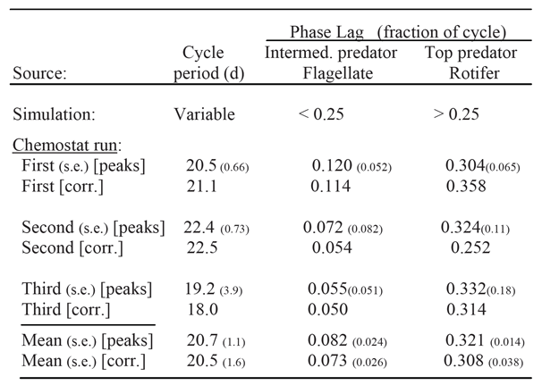

Literature cited

Becks, L., S. P. Ellner, L. E. Jones, and N. G. Hairston, Jr. 2010. Reduction of adaptive genetic diversity radically alters eco-evolutionary community dynamics. Ecology letters 13:989–997.

Cabrera, J. L. O. 2009. locpol: Kernel local polynomial regression. R package version 0.4-0. http://CRAN.R-project.org/package=locpol

Fussmann, G. F., S. P. Ellner, K. W. Shertzer, and N. G. Hairston, Jr. 2000. Crossing the Hopf bifurcation in a live predator–prey system. Science 290:1358–1360.

Guillard, R. R. L., and J. H. Ryther. 1962. Studies of marine planktonic: I*. Cyclotella nana* Hustedt, and *Detonula confervacea* (Cleve) Gran. Canadian Journal of Microbiology 8:229–239.

Yoshida, T., L. E. Jones, S. P. Ellner, G. F. Fussmann, and N. G. Hairston, Jr. 2003. Rapid evolution drives ecological dynamics in a predator–prey system. Nature 424:303–306.

[Back to E094-065]